# Project: No show Appointmnents Dataset Investigation

- Introduction
- Data Wrangling
- Exploratory Data Analysis
- Conclusions and Limitations
- References for analysis

## Introduction

> The dataset for this investigation is the No-show appointments dataset. It is based on informataion collected from more than 100 thousand medical appointments in brasil and based on gathering data on weather patients showed up for appointments or not. Several variables are used to capture the appropriate data to dissect the question on weather a patient will show up for appointments or not.

> In our attempt to understand the insight of the data, we shall focuse on just two questions that goes thus;
> 1. Does being an alcoholic influence ones likelihood of showing up for hospital appointments?
> 2. Do all those who receive SMSs show up for appointments? and is there any association between receiving an SMS and showing up for appointments?

```python
#Here we imported all the python libraries that are important for our analysis
import pandas as pd
import numpy as np
from scipy.stats import chi2_contingency as cqt
import matplotlib.pyplot as plt
%matplotlib inline
```

## Data Wrangling

> In this section of our data analysis process, we got to undertsand the nature of the data, the nature of the variables and their usability as far as answering our questions are concerned. We Further cleaned the data to suit our analysis.

### General Properties

```python
#   data loaded into the dataframe
df=pd.read_csv('noshowappointments-kagglev2-may-2016.csv')
```

> From our Head method and its output below, we can see all the column names and sample rows. It can be observed that hipertension is not well spelt and hence a variable that might need to be modified. From the variable Scholarship to SMS received, they seem to be coded and as a result might need further processing.

```python
df.head()
```

|  | PatientId | AppointmentID | Gender | ScheduledDay | AppointmentDay | Age | Neighbourhood | Scholarship | Hipertension | Diabetes | Alcoholism | Handcap | SMS_received | No-show |
| --- | --- | --- | --- | --- | --- | --- | --- | --- | --- | --- | --- | --- | --- | --- |
| 0 | 2.987250e+13 | 5642903 | F | 2016-04-29T18:38:08Z | 2016-04-29T00:00:00Z | 62 | JARDIM DA PENHA | 0 | 1 | 0 | 0 | 0 | 0 | No |
| 1 | 5.589978e+14 | 5642503 | M | 2016-04-29T16:08:27Z | 2016-04-29T00:00:00Z | 56 | JARDIM DA PENHA | 0 | 0 | 0 | 0 | 0 | 0 | No |
| 2 | 4.262962e+12 | 5642549 | F | 2016-04-29T16:19:04Z | 2016-04-29T00:00:00Z | 62 | MATA DA PRAIA | 0 | 0 | 0 | 0 | 0 | 0 | No |
| 3 | 8.679512e+11 | 5642828 | F | 2016-04-29T17:29:31Z | 2016-04-29T00:00:00Z | 8 | PONTAL DE CAMBURI | 0 | 0 | 0 | 0 | 0 | 0 | No |
| 4 | 8.841186e+12 | 5642494 | F | 2016-04-29T16:07:23Z | 2016-04-29T00:00:00Z | 56 | JARDIM DA PENHA | 0 | 1 | 1 | 0 | 0 | 0 | No |

> There are a total of **110,527** rows in and **14** columns in this dataset as seen from the shape function.

```python
df.shape
```

```
(110527, 14)
```

> From the info method, it is observed that this data has no null data entries as all variable show a total of 110527 entries. It is further seen that variables like diabetes are integers hence a need for them to be changed per our nature of analysis.

```python
df.info()
```

```
<class 'pandas.core.frame.DataFrame'>
RangeIndex: 110527 entries, 0 to 110526
Data columns (total 14 columns):
 #   Column          Non-Null Count   Dtype
---  ------          --------------   -----
 0   PatientId       110527 non-null  float64
 1   AppointmentID   110527 non-null  int64
 2   Gender          110527 non-null  object
 3   ScheduledDay    110527 non-null  object
 4   AppointmentDay  110527 non-null  object
 5   Age             110527 non-null  int64
 6   Neighbourhood   110527 non-null  object
 7   Scholarship     110527 non-null  int64
 8   Hipertension    110527 non-null  int64
 9   Diabetes        110527 non-null  int64
 10  Alcoholism      110527 non-null  int64
 11  Handcap         110527 non-null  int64
 12  SMS_received    110527 non-null  int64
 13  No-show         110527 non-null  object
dtypes: float64(1), int64(8), object(5)
memory usage: 11.8+ MB
```

> To complememnt the data already observed from the info() method above, it can be see that no variables are null (empty) as seen from the combine use of the isnull and sum functions.

```python
df.isnull().sum()
```

```
PatientId         0
AppointmentID     0
Gender            0
ScheduledDay      0
AppointmentDay    0
Age               0
Neighbourhood     0
Scholarship       0
Hipertension      0
Diabetes          0
Alcoholism        0
Handcap           0
SMS_received      0
No-show           0
dtype: int64
```

> In an attempt to get all the columns that return True for duplicates in other to determine if there are duplicates in the data, it was observed that no columns were returned as seen below. This means our data is good to go as far as this area is concerned and we have no need to handle duplicates.

```python
df[df.duplicated()]
```

|  | PatientId | AppointmentID | Gender | ScheduledDay | AppointmentDay | Age | Neighbourhood | Scholarship | Hipertension | Diabetes | Alcoholism | Handcap | SMS_received | No-show |
| --- | --- | --- | --- | --- | --- | --- | --- | --- | --- | --- | --- | --- | --- | --- |

```python
df.describe()
```

|  | PatientId | AppointmentID | Age | Scholarship | Hipertension | Diabetes | Alcoholism | Handcap | SMS_received |
| --- | --- | --- | --- | --- | --- | --- | --- | --- | --- |
| count | 1.105270e+05 | 1.105270e+05 | 110527.000000 | 110527.000000 | 110527.000000 | 110527.000000 | 110527.000000 | 110527.000000 | 110527.000000 |
| mean | 1.474963e+14 | 5.675305e+06 | 37.088874 | 0.098266 | 0.197246 | 0.071865 | 0.030400 | 0.022248 | 0.321026 |
| std | 2.560949e+14 | 7.129575e+04 | 23.110205 | 0.297675 | 0.397921 | 0.258265 | 0.171686 | 0.161543 | 0.466873 |
| min | 3.921784e+04 | 5.030230e+06 | -1.000000 | 0.000000 | 0.000000 | 0.000000 | 0.000000 | 0.000000 | 0.000000 |
| 25% | 4.172614e+12 | 5.640286e+06 | 18.000000 | 0.000000 | 0.000000 | 0.000000 | 0.000000 | 0.000000 | 0.000000 |
| 50% | 3.173184e+13 | 5.680573e+06 | 37.000000 | 0.000000 | 0.000000 | 0.000000 | 0.000000 | 0.000000 | 0.000000 |
| 75% | 9.439172e+13 | 5.725524e+06 | 55.000000 | 0.000000 | 0.000000 | 0.000000 | 0.000000 | 0.000000 | 1.000000 |
| max | 9.999816e+14 | 5.790484e+06 | 115.000000 | 1.000000 | 1.000000 | 1.000000 | 1.000000 | 4.000000 | 1.000000 |

```
0    108286
1      2042
2       183
3        13
4         3
Name: Handcap, dtype: int64
```

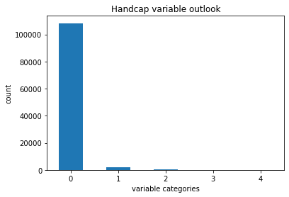

```python
# labling and ploting handcap variable
df['Handcap'].value_counts().plot(kind='bar',title='Handcap variable outlook')
plt.ylabel('count')
plt.xticks(rotation=0)
plt.xlabel('variable categories')
# Table of handcap variable
df['Handcap'].value_counts()
```

Furthermore, an outlook of seeminly binary variables was observed and confimed as seen below

|  | 0 | 1 |
| --- | --- | --- |
| Scholarship | 99666 | 10861 |
| Hipertension | 88726 | 21801 |
| Diabetes | 102584 | 7943 |
| Alcoholism | 107167 | 3360 |
| SMS_received | 75045 | 35482 |

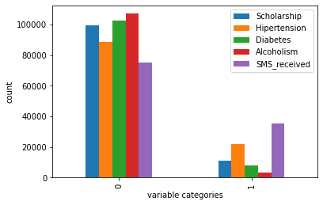

```python
# binary_c refers to all our binary variables that had 0 and 1 as their data interpreted as No and yes
binary_c=df.iloc[:,np.r_[7:11,12]]
#plot of coded binary variables
binary_c.apply(pd.Series.value_counts).plot(kind='bar')
#labels of chart showcasing the variables
plt.ylabel('count')
plt.xlabel('variable categories')
# Table of binary variables
binary_c.apply(pd.Series.value_counts).T
```

> Since Gender and No-show variables are important in our questions, we looked at their nature. Both were ok category wise but No-show variable is not in a very friendly nature for the interpreter hence the hyphen(-) needs to be removed and converted to an underscore(_)

```python
df.Gender.value_counts(), df['No-show'].value_counts()
```

```
(F    71840
 M    38687
 Name: Gender, dtype: int64,
 No     88208
 Yes    22319
 Name: No-show, dtype: int64)
```

### No Show Appointmets Data Cleaning

> In the cell below, Hipertension variable as well as No-show variable were renamed to their grammatically correct as well as programmatically comfortable spellings respectively.

```python
#renamimg of the Hipertension and No-show variables
df.rename({'Hipertension':'Hypertension','No-show':'No_show'}, axis=1, inplace=True)
df.head(0)
```

|  | PatientId | AppointmentID | Gender | ScheduledDay | AppointmentDay | Age | Neighbourhood | Scholarship | Hypertension | Diabetes | Alcoholism | Handcap | SMS_received | No_show |
| --- | --- | --- | --- | --- | --- | --- | --- | --- | --- | --- | --- | --- | --- | --- |

> In the cells below, The coding in the various columns with 0 and 1 responses were decoded to their respective values of 'No' and 'Yes'. This is to ease anaylsis and labling when it is time for visualisations

```python
# No or Yes Variables replacement
r_columns=df.iloc[:,np.r_[7:11,12]]
for i in r_columns.columns:
    df[i].replace([0,1],['No','Yes'],inplace=True)
df.head().T
```

|  | 0 | 1 | 2 | 3 | 4 |
| --- | --- | --- | --- | --- | --- |
| PatientId | 29872499824296.0 | 558997776694438.0 | 4262962299951.0 | 867951213174.0 | 8841186448183.0 |
| AppointmentID | 5642903 | 5642503 | 5642549 | 5642828 | 5642494 |
| Gender | F | M | F | F | F |
| ScheduledDay | 2016-04-29T18:38:08Z | 2016-04-29T16:08:27Z | 2016-04-29T16:19:04Z | 2016-04-29T17:29:31Z | 2016-04-29T16:07:23Z |
| AppointmentDay | 2016-04-29T00:00:00Z | 2016-04-29T00:00:00Z | 2016-04-29T00:00:00Z | 2016-04-29T00:00:00Z | 2016-04-29T00:00:00Z |
| Age | 62 | 56 | 62 | 8 | 56 |
| Neighbourhood | JARDIM DA PENHA | JARDIM DA PENHA | MATA DA PRAIA | PONTAL DE CAMBURI | JARDIM DA PENHA |
| Scholarship | No | No | No | No | No |
| Hypertension | Yes | No | No | No | Yes |
| Diabetes | No | No | No | No | Yes |
| Alcoholism | No | No | No | No | No |
| Handcap | 0 | 0 | 0 | 0 | 0 |
| SMS_received | No | No | No | No | No |
| No_show | No | No | No | No | No |

> The replacement of 0 to No and 1 To Yes meant that the data types of those variables had to change from integers to strings as seen below.

```python
df.dtypes
```

```
PatientId         float64
AppointmentID       int64
Gender             object
ScheduledDay       object
AppointmentDay     object
Age                 int64
Neighbourhood      object
Scholarship        object
Hypertension       object
Diabetes           object
Alcoholism         object
Handcap             int64
SMS_received       object
No_show            object
dtype: object
```

> Since The Handcap variable is not vital to the answerioing of our questions and it had discrepancies as the data never gave us sufficient information about its nature and we could not rpoperly deduce weather the additional categories were true categories or were mistakes, we decided to drop the variable as seen below.

```python
df.drop('Handcap',axis=1,inplace=True)
df.head(5).T
```

|  | 0 | 1 | 2 | 3 | 4 |
| --- | --- | --- | --- | --- | --- |
| PatientId | 29872499824296.0 | 558997776694438.0 | 4262962299951.0 | 867951213174.0 | 8841186448183.0 |
| AppointmentID | 5642903 | 5642503 | 5642549 | 5642828 | 5642494 |
| Gender | F | M | F | F | F |
| ScheduledDay | 2016-04-29T18:38:08Z | 2016-04-29T16:08:27Z | 2016-04-29T16:19:04Z | 2016-04-29T17:29:31Z | 2016-04-29T16:07:23Z |
| AppointmentDay | 2016-04-29T00:00:00Z | 2016-04-29T00:00:00Z | 2016-04-29T00:00:00Z | 2016-04-29T00:00:00Z | 2016-04-29T00:00:00Z |
| Age | 62 | 56 | 62 | 8 | 56 |
| Neighbourhood | JARDIM DA PENHA | JARDIM DA PENHA | MATA DA PRAIA | PONTAL DE CAMBURI | JARDIM DA PENHA |
| Scholarship | No | No | No | No | No |
| Hypertension | Yes | No | No | No | Yes |
| Diabetes | No | No | No | No | Yes |
| Alcoholism | No | No | No | No | No |
| SMS_received | No | No | No | No | No |
| No_show | No | No | No | No | No |

> Lastly, we changed the M and F in the Gender variable to Male and Female respectivel as seen below.

```python
df.Gender.replace(['M','F'],['Male','Female'],inplace=True)
df.head(3)
```

|  | PatientId | AppointmentID | Gender | ScheduledDay | AppointmentDay | Age | Neighbourhood | Scholarship | Hypertension | Diabetes | Alcoholism | SMS_received | No_show |
| --- | --- | --- | --- | --- | --- | --- | --- | --- | --- | --- | --- | --- | --- |
| 0 | 2.987250e+13 | 5642903 | Female | 2016-04-29T18:38:08Z | 2016-04-29T00:00:00Z | 62 | JARDIM DA PENHA | No | Yes | No | No | No | No |
| 1 | 5.589978e+14 | 5642503 | Male | 2016-04-29T16:08:27Z | 2016-04-29T00:00:00Z | 56 | JARDIM DA PENHA | No | No | No | No | No | No |
| 2 | 4.262962e+12 | 5642549 | Female | 2016-04-29T16:19:04Z | 2016-04-29T00:00:00Z | 62 | MATA DA PRAIA | No | No | No | No | No | No |

## Exploratory Data Analysis

### Research Question 1 : Does being an alcoholic influence ones likelihood of showing up for hospital appointments?

> To answer this question, we had to initially look at the nature of the variables involved in answering the questions which is Alcoholism and No_show.

From the analysis in the two cells below, it can be seen that **107,167** individual were not alcoholic compared to **3,360** who were alcoholic. This clearly shows that there were relaticely small percentage of alcoholics in the population as it can be seen from our plots and percentages(**3.04%**) compared to **96.96%** non alcoholic.

```python
# grouping alcoholics to those who are not
al_num=df.Alcoholism.value_counts()

# Getting the percentages of those alcoholic or not and rounding to 2 decimal places
al_perc=df.Alcoholism.value_counts(normalize=True)*100
ro_perc=al_perc.round(2)

(al_num,ro_perc)
```

```
(No     107167
 Yes      3360
 Name: Alcoholism, dtype: int64,
 No     96.96
 Yes     3.04
 Name: Alcoholism, dtype: float64)
```

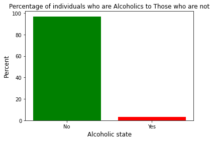

```python
# definig parameters needed for plotting percentages of the groups
location=np.arange(len(ro_perc))
heights=ro_perc
labels=ro_perc.index.str.replace('_', ' ').str.title()
# Plotting a bar chart and labeling
plt.bar(location,heights,tick_label=labels, color=['green','red'])
plt.title('Percentage of individuals who are Alcoholics to Those who are not',fontsize=12)
plt.ylabel('Percent',fontsize=12)
plt.xlabel('Alcoholic state',fontsize=12)
```

```python
# grouping those who showed up by those who did not
sh_num=df.No_show.value_counts()

# Getting the percentages of those who showed up or not and rounding to 2 decimal places
sh_perc=df.No_show.value_counts(normalize=True)*100
ro_sperc=sh_perc.round(2)

(sh_num,ro_sperc)
```

```
(No     88208
 Yes    22319
 Name: No_show, dtype: int64,
 No     79.81
 Yes    20.19
 Name: No_show, dtype: float64)
```

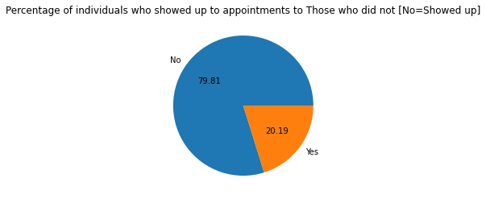

```python
# definig parameters needed for plotting percentages of the groups
heights=ro_sperc
labels=ro_sperc.index.str.replace('_', ' ').str.title()
# Plotting a pie chart and adding title
plt.pie(heights,labels=labels, autopct='%.2f')
plt.title('Percentage of individuals who showed up to appointments to Those who did not [No=Showed up]',fontsize=12)
```

> Following on to undertsand the relationship between both variables, a cross table was used. From the table, it was observed that in the category of those who were alcoholic, **2683(2.4%)** indicated to have shown up to their appointment in contrast to **677(0.6%)** who never showed up. A similar trend is seen in Those who were never alcoholic indicating that alcoholism has nothing to do with one's likelihood of showing up for appointments as can be visually seen in the comparison clustered bar chart below.

```python
# c_analysis computes the cross table for both variables
# cp_analysis gets various proportions  and round them down to 3 decimal places
c_analysis=pd.crosstab(df['Alcoholism'],df['No_show'])
cp_analysis=pd.crosstab(df['Alcoholism'],df['No_show'],normalize=True).round(3)*100

# crosstable values
c_analysis
```

| No_show Alcoholism | No | Yes |
| --- | --- | --- |
| No | 85525 | 21642 |
| Yes | 2683 | 677 |

```python
# crosstable proportions
cp_analysis
```

| No_show Alcoholism | No | Yes |
| --- | --- | --- |
| No | 77.4 | 19.6 |
| Yes | 2.4 | 0.6 |

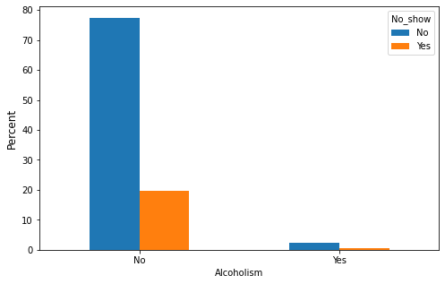

```python
# The following function takes in a cross table in proportion and plots a clustered bar chart to compare both variables
def bi_chart(chart_frame):
    # Bar plot from cross table
    chart_frame.plot(kind='bar',figsize=(8,5))
    plt.xticks(rotation=0)
    plt.ylabel('Percent',fontsize='12')

bi_chart(cp_analysis)
```

A chi square test can be used to determine association between two categorical variables. At the 95% confidence level, it is observed that no association exist as the p value is **greater than 0.05(0.965)**.

```python
# Here, c indicates the Chi- square value, P indicates the p value and dof is the degree of freedom
# Using the scipy.stats module, the contingency table of both categories seen above is passed to  this method and test computed.
c, p, dof, expected = cqt(c_analysis)

# Test statistics and p value rounded to 5 decimals
c.round(5), p.round(5)
```

```
(0.00188, 0.96542)
```

### Research Question 2: Do all those who receive SMSs show up for appointments? and is there any association between receiving an SMS and showing up for appointments?

> Following from the first question, this question follows the sam pathern and was anaylsed in a similar manner. Since the nature of the No_show varaible is already known from our previous question, only SMS_received was explored here.

From our data, it was seen that **75,045(67.90%)** of individuals never received SMSs while **35.482(32.10%)** received SMSs, indicating that less individuals received SMSs compared to those who did not. This is clearly visible both as frequencies and proportions as well as through a plot as seen below.

```python
# grouping Those who received SMSs to those who did not
sms_num=df.SMS_received.value_counts()

# Getting the percentages of those who received SMSs or not and rounding to 2 decimal places
sms_perc=df.SMS_received.value_counts(normalize=True)*100
sms_perc=sms_perc.round(2)

(sms_num,sms_perc)
```

```
(No     75045
 Yes    35482
 Name: SMS_received, dtype: int64,
 No     67.9
 Yes    32.1
 Name: SMS_received, dtype: float64)
```

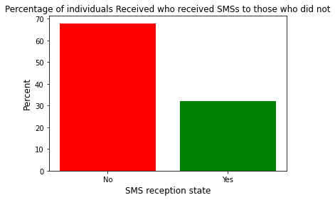

```python
# definig parameters needed for plotting percentages of the groups
location=np.arange(len(sms_perc))
heights=sms_perc
labels=sms_perc.index.str.replace('_', ' ').str.title()
# Plotting a bar chart and labeling
plt.bar(location,heights,tick_label=labels, color=['red','green'])
plt.title('Percentage of individuals Received who received SMSs to those who did not',fontsize=12)
plt.ylabel('Percent',fontsize=12)
plt.xlabel('SMS reception state',fontsize=12)
```

From our cross table, it was observed that among those who recievd SMSs, not all of them showed up for appointments however a majority showed for the appointments though this can be counteracted as even those who never received had greater proportions on showing up for appointments. This is all well documented in frequencies, proportions and charts below.

```python
# cs_analysis computes the cross table for both variables
# cp_analysis gets various proportions  and round them down to 3 decimal places
cs_analysis=pd.crosstab(df['SMS_received'],df['No_show'])
csp_analysis=pd.crosstab(df['SMS_received'],df['No_show'],normalize=True).round(3)*100

# crosstable values
cs_analysis
```

| No_show SMS_received | No | Yes |
| --- | --- | --- |
| No | 62510 | 12535 |
| Yes | 25698 | 9784 |

```python
# crosstable proportions
csp_analysis
```

| No_show SMS_received | No | Yes |
| --- | --- | --- |
| No | 56.6 | 11.3 |
| Yes | 23.3 | 8.9 |

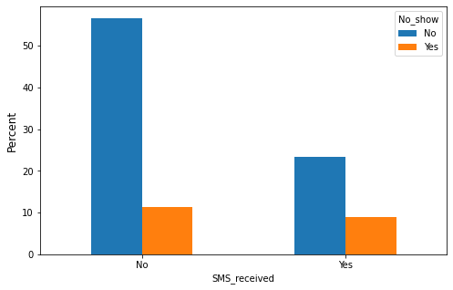

```python
# Here, we called on the bi_chart function earlier written that takes in cross table proportions
# and plots a clustered chart as seen below
bi_chart(csp_analysis)
```

Accessing the statistoical association at the 95% confidence level, it is observed that the p value is less than 0.05(0.0), implying a statistical association between both variables as seen below.

```python
# Here, c indicates the Chi- square value, P indicates the p value and dof is the degree of freedom
# Using the scipy.stats module, the contingency table of both categories seen above is passed to  this method and test computed.
c, p, dof, expected = cqt(cs_analysis)

# Test statistics and p value rounded to 5 decimals
c.round(5), p.round(5)
```

```
(1766.06766, 0.0)
```

## Conclusions

Regarding research question 1, it can be speculatively observed that more persons showed up for appointments both in categories of those who were alcoholic and were not. This visibly meant that alcoholism might not affect ones likelihood of showing up for appointments. Though not required in this analysis, further statistical tests(Chi-square) were carried out to ascertain these results and it was confirmed that no statistical associations exist between alcoholism and Ones likelihood of showing up for appointments **(p>0.05)** hence we can safetly conclude that alcoholism does not influence ones likelihood of showing up for appointments.

Regarding research question 2, it was seen that among those who received SMSs, not all of them showed up for appointments as **23.3%** showed up while **8.9%** did not show up.

Though not required, following on to asses the statistical association between the reception of SMSs and showing up for appointments, a statistically significant association was obserced at the 95% confidence level as the p value was **less than 0.05(0.0)**. This meant the data provided enough evidence for us to confirm that ones reception of an SMS can influence their showing up for appointments or not.

## Limitations to the study

1. The dataset had certain challenges associated with coding as there was no adeqaute information from the data description of variable values. This could lead to misinterpretation and misrepresentation of data. This is visbly seen in the Handcap variable in which several categories originated and as a result the variable had to be ultimately droped. This could be avoided by adding an appropriate coding section for the data.
2. Per the original demand of the analysis, using only descriptives is not sufficient to determine statistical associations, hence following this original structure, our analysis would have provided only tentative results. This was however handled as we used the Chi-squared test in our analysis.

# The following references played an important role in assisting this analysis

1. Shanelynn.ie. 2022. Pandas iloc and loc – quickly select data in DataFrames. [online] Available at: https://www.shanelynn.ie/pandas-iloc-loc-select-rows-and-columns-dataframe/#:~:text=iloc%20returns%20a%20Pandas%20Series,if%20you%20require%20DataFrame%20output. [Accessed 4 August 2022].
2. DataFrame?, H., Petrou, T. and Tochilov, S., 2022. How to get value counts for multiple columns at once in Pandas DataFrame?. [online] Stack Overflow. Available at: https://stackoverflow.com/questions/32589829/how-to-get-value-counts-for-multiple-columns-at-once-in-pandas-dataframe [Accessed 4 August 2022].
3. (numpy)?, W., 2022. What does np.r_ do (numpy)?. [online] Stack Overflow. Available at: https://stackoverflow.com/questions/30597869/what-does-np-r-do-numpy [Accessed 4 August 2022].
4. w3resource. 2022. Pandas: Data Manipulation - crosstab function - w3resource. [online] Available at: https://www.w3resource.com/pandas/crosstab.php [Accessed 6 August 2022].
5. datagy. 2022. Counting Values in Pandas with value_counts • datagy. [online] Available at: https://datagy.io/pandas-value-counts/ [Accessed 6 August 2022].
6. GeeksforGeeks. 2022. Plot a pie chart in Python using Matplotlib - GeeksforGeeks. [online] Available at: https://www.geeksforgeeks.org/plot-a-pie-chart-in-python-using-matplotlib/ [Accessed 6 August 2022].
7. Predictive Hacks. 2022. How to run Chi-Square Test in Python – Predictive Hacks. [online] Available at: https://predictivehacks.com/how-to-run-chi-square-test-in-python/ [Accessed 6 August 2022].